# HW: Python Bootcamp

- No prior coding experience is needed to learn Python for data analytics. Python is one of the most popular tools for advanced data analytics and big data analysis. You will learn Python basics in this tutorial.

Why you should know Python for data analytics?

- Python will allow you to do any type of data analytics you can think of, including HR analytics, SCM analytics, social media analytics, Financial analytics, Sports analytics, ... http://www.kdnuggets.com/2015/05/r-vs-python-data-science.html

Instruction

- Rename this Ipython Notebook as "yourlastname_firstinitial_HW_Python_Bootcamp".
- Include your name & K-State Honor Code in the below markdown.
- And you shoud thorougly practice every single line of the codes below and review the output. You're encouraged to watch the video lecture.

# Nicole Becker, "On my honor, as a student, I have neither given nor received unauthorized aid on this academic work."

# Variables & Numbers

https://pythonspot.com/python-numbers/

```python
x = 10              # an integer ... in Python you can add comments using #
f = 10.525       # a floating real point
name = "Python"    # a string

print(x)
print(f)
print(name)
```

```
10
10.525
Python
```

```python
x = 3
y = 8

sum = x + y

print(sum)
```

```
11
```

```python
y = 2
print (x+y)
```

```
5
```

```python
# Create three variables (string, integer, float)
# display them
# display the sum of integer and float
a = 7
b = 7.5789
c = "Wildcats"

print (a, b, c)
print (a+b)
```

```
7 7.5789 Wildcats
14.5789
```

```python
x = 3.555555555              # a float = a decimal number
f = 10.525525                 # a float
```

```python
print(x, f)
```

```
3.555555555 10.525525
```

```python
sum = x + f
print(sum)
print("%.2f" % sum)
```

```
14.081080555
14.08
```

```python
# Create three float values
# display them
# display the sum of the three values (show two decimal points only)

j = 3.456
k = 2.33333
i = 4.6892

print(j, k, i)
sum = j+k+i
print("%.2f"% sum)
```

```
3.456 2.33333 4.6892
10.48
```

# Strings

https://pythonspot.com/python-strings/

```python
s = "Hello Python"
print(s)       # prints whole string
print(s[0])    # prints "H"
print(s[0:2])  # prints "He"
```

```
Hello Python
H
He
```

```python
his_name = "Kevin"
his_age = 20

print("%s is %s years old" % (his_name, his_age))
```

```
Kevin is 20 years old
```

```python
# create two string variables and one number variable
# concantenate all three values in a single line

first_name = "Bill"
last_name = "Snyder"
children = 4

print("%s %s has %s children" % (first_name, last_name, children))
```

```
Bill Snyder has 4 children
```

# IF-statements

https://pythonspot.com/conditional-statements/

```python
a = "you are beautiful"
b = "you are awesome"

if a == b:
    print('equal')
else:
    print('not equal')
```

```
not equal
```

```python
a = 100
b = 10
if a < b:
   print('a smaller than 10')
else:
   print('a is bigger than 10 or equal')
```

```
a is bigger than 10 or equal
```

```python
# create an if statement comparing two string values and print the result

a = -4
b = -2
c = 12

if (a+b+c) < 0:
    print("loss")
else:
    print("gain")
```

```
gain
```

# Lists

Each value is assigned into an **index** or a **position** ... this is like **address** ... **the first index is zero; the second index is one**

Lists can be thought of as a series of boxes. Each box has a different value. For example, the boxes created by demolist = ['life', 42, 'the universe', 6, 'and', 9] would look like this:

[figure not shown]

Each box is referenced by its number so the statement demolist[0] would get 'life', demolist[1] would get 42 and so on up to demolist[5] getting 9.

```python
l = [ "Drake", "Derp", "Derek", "Dominique", 42, 6, "Universe", 9]

print(l)     # prints all elements
print(l[0])  # print first element ... each value is assigned into an index or a position ... the first index is zero
print(l[1])  # prints second element ... the second index is one
print(l[0:2]) # print the first two items
print(l[-1])  # print the last item
```

```
['Drake', 'Derp', 'Derek', 'Dominique', 42, 6, 'Universe', 9]
Drake
Derp
['Drake', 'Derp']
9
```

```python
len(l)
```

```
8
```

```python
# create a list of string and number values
# count them and show the results
# display the last value in the list

a = [ "milk", "bread", "eggs", "cheese",22, 7, "candy"]
b = len(a)
print (b)
print(a[-1])
```

```
7
candy
```

# Loops

https://pythonspot.com/loops/

```python
# below is a list of data
items = [ "Abby","Brenda","Cindy","Diddy", 100 ]

for i in items:
    print(i)
```

```
Abby
Brenda
Cindy
Diddy
100
```

```python
items = [ "Abby","Brenda","Cindy","Diddy" ]

for i in items:
    print(i + " is wonderful!")
```

```
Abby is wonderful!
Brenda is wonderful!
Cindy is wonderful!
Diddy is wonderful!
```

```python
# below is a list of data
items = [ "Abby","Brenda","Cindy","Diddy", 100 ]

for i in items:
    print(i)

print("There are %s items in the list" %len(items))
```

```
Abby
Brenda
Cindy
Diddy
100
There are 5 items in the list
```

```python
# You can include Youtube video in Ipython notebook
from IPython.display import YouTubeVideo
YouTubeVideo('k0xgjUhEG3U')
```

[video not shown]

```python
# write a looping statement processing a list of strings and numbers
dogs = ["golden retriever", "poodle", 10, "beagle",12, "german shepherd"]

for i in dogs:
    print (i)
print("dogs are amazing")

# show how many values in the list
len(dogs)
```

```
golden retriever
poodle
10
beagle
12
german shepherd
dogs are amazing
```

```
6
```

```python
# range(stop)
for i in range(10):
    print(i)
```

```
0
1
2
3
4
5
6
7
8
9
```

```python
# range([start], stop[, step])
for i in range(2,10,2):
    print(i)
```

```
2
4
6
8
```

```python
# write a looping statement using range. Print "Hello Data Analytics & Python" 10 times
for j in range(10):
    print("Hello Data Analytics & Python")
```

```
Hello Data Analytics & Python
Hello Data Analytics & Python
Hello Data Analytics & Python
Hello Data Analytics & Python
Hello Data Analytics & Python
Hello Data Analytics & Python
Hello Data Analytics & Python
Hello Data Analytics & Python
Hello Data Analytics & Python
Hello Data Analytics & Python
```

# Read & Write File

Panda is a popular Python package for reading and processing data.

You can import files in csv and excel

```python
# Read Excel file
import pandas as pd

data = pd.read_excel('data/sales_sample.xlsx')
data

#to read csv file
# data = pd.read_csv('data/sales_sample.csv')
```

|  | Order ID | Order Date | Order Quantity | Sales | Profit | Unit Price | Shipping Cost | Zip Code | Region | Customer Segment | Product Category | Product Sub-Category | Product Base Margin | Ship Date |
| --- | --- | --- | --- | --- | --- | --- | --- | --- | --- | --- | --- | --- | --- | --- |
| 0 | 3 | 2010-08-26 | 6 | 261.5400 | -213.2500 | 38.94 | 35.00 | 7514 | East | Small Business | Office Supplies | Storage & Organization | 0.80 | 2010-09-02 |
| 1 | 6 | 2012-01-03 | 2 | 6.9300 | -4.6400 | 2.08 | 2.56 | 10457 | East | Corporate | Office Supplies | Scissors, Rulers and Trimmers | 0.55 | 2012-01-04 |
| 2 | 32 | 2011-05-28 | 15 | 140.5600 | -128.3800 | 8.46 | 8.99 | 44197 | Central | Corporate | Technology | Computer Peripherals | 0.79 | 2011-05-29 |
| 3 | 32 | 2011-05-28 | 24 | 1761.4000 | -1748.5600 | 70.89 | 89.30 | 44197 | Central | Corporate | Furniture | Tables | 0.72 | 2011-05-29 |
| 4 | 32 | 2011-05-28 | 23 | 160.2335 | -85.1290 | 7.99 | 5.03 | 44197 | Central | Corporate | Technology | Telephones and Communication | 0.60 | 2011-05-30 |
| 5 | 32 | 2011-05-28 | 26 | 2808.0800 | 1054.8200 | 107.53 | 5.81 | 44197 | Central | Corporate | Furniture | Office Furnishings | 0.65 | 2011-05-30 |
| 6 | 35 | 2011-09-04 | 30 | 288.5600 | 60.7200 | 9.11 | 2.25 | 49822 | Central | Corporate | Office Supplies | Pens & Art Supplies | 0.52 | 2011-09-05 |
| 7 | 35 | 2011-09-04 | 14 | 1892.8480 | 48.9870 | 155.99 | 8.99 | 49822 | Central | Corporate | Technology | Telephones and Communication | 0.58 | 2011-09-06 |
| 8 | 36 | 2011-09-15 | 46 | 2484.7455 | 657.4770 | 65.99 | 4.20 | 6074 | East | Home Office | Technology | Telephones and Communication | 0.55 | 2011-09-15 |
| 9 | 65 | 2011-01-28 | 32 | 3812.7300 | 1470.3000 | 115.79 | 1.99 | 19936 | East | Corporate | Technology | Computer Peripherals | 0.49 | 2011-01-29 |
| 10 | 66 | 2008-12-02 | 41 | 108.1500 | 7.5700 | 2.88 | 0.70 | 27006 | South | Consumer | Office Supplies | Pens & Art Supplies | 0.56 | 2008-12-02 |
| 11 | 69 | 2009-04-16 | 42 | 1186.0600 | 511.6900 | 30.93 | 3.92 | 43567 | Central | Corporate | Furniture | Office Furnishings | 0.44 | 2009-04-18 |
| 12 | 69 | 2009-04-16 | 28 | 51.5300 | 0.3500 | 1.68 | 0.70 | 43567 | Central | Corporate | Office Supplies | Pens & Art Supplies | 0.60 | 2009-04-18 |
| 13 | 70 | 2010-10-30 | 46 | 7804.5300 | 2057.1660 | 205.99 | 5.99 | 27006 | South | Home Office | Technology | Telephones and Communication | 0.59 | 2010-11-04 |
| 14 | 70 | 2010-10-30 | 48 | 90.0500 | -107.0000 | 1.86 | 2.58 | 27006 | South | Home Office | Office Supplies | Rubber Bands | 0.82 | 2010-11-04 |
| 15 | 96 | 2009-02-27 | 37 | 4158.1235 | 1228.8870 | 125.99 | 8.99 | 73301 | Central | Home Office | Technology | Telephones and Communication | 0.55 | 2009-03-01 |
| 16 | 97 | 2009-12-11 | 26 | 75.5700 | 28.2400 | 2.89 | 0.50 | 85354 | West | Consumer | Office Supplies | Labels | 0.38 | 2009-12-12 |
| 17 | 129 | 2012-10-01 | 4 | 32.7200 | -22.5900 | 6.48 | 8.19 | 6439 | East | Corporate | Office Supplies | Paper | 0.37 | 2012-10-10 |
| 18 | 130 | 2012-03-20 | 29 | 575.1100 | 71.7500 | 18.97 | 9.03 | 32003 | South | Corporate | Office Supplies | Paper | 0.37 | 2012-03-21 |
| 19 | 130 | 2012-03-20 | 3 | 461.8900 | -356.1200 | 150.98 | 13.99 | 32003 | South | Corporate | Technology | Office Machines | 0.38 | 2012-03-22 |
| 20 | 130 | 2012-03-20 | 23 | 236.4600 | -134.3100 | 9.71 | 9.45 | 32003 | South | Corporate | Office Supplies | Storage & Organization | 0.60 | 2012-03-23 |
| 21 | 132 | 2010-04-23 | 27 | 192.8140 | -86.1960 | 7.99 | 5.03 | 21290 | South | Consumer | Technology | Telephones and Communication | 0.60 | 2010-04-24 |
| 22 | 132 | 2010-04-23 | 30 | 4011.6500 | -603.8000 | 130.98 | 54.74 | 21290 | South | Consumer | Furniture | Bookcases | 0.69 | 2010-04-26 |
| 23 | 134 | 2012-03-13 | 11 | 1132.6000 | -310.2100 | 95.99 | 35.00 | 81221 | West | Home Office | Office Supplies | Storage & Organization | 0.82 | 2012-03-15 |
| 24 | 135 | 2011-09-02 | 25 | 125.8500 | -89.2500 | 4.98 | 4.62 | 43054 | Central | Consumer | Technology | Computer Peripherals | 0.64 | 2011-09-04 |
| 25 | 166 | 2011-07-25 | 10 | 567.9360 | -126.0930 | 65.99 | 8.99 | 84001 | West | Consumer | Technology | Telephones and Communication | 0.55 | 2011-07-27 |
| 26 | 193 | 2010-06-20 | 14 | 174.8900 | -37.0400 | 12.44 | 6.27 | 85233 | West | Consumer | Office Supplies | Storage & Organization | 0.57 | 2010-06-22 |
| 27 | 194 | 2012-02-16 | 49 | 329.0300 | -197.2500 | 7.28 | 7.98 | 30002 | South | Corporate | Furniture | Office Furnishings | 0.42 | 2012-02-18 |
| 28 | 194 | 2012-02-16 | 6 | 20.1900 | -13.4400 | 3.14 | 1.92 | 30002 | South | Corporate | Office Supplies | Scissors, Rulers and Trimmers | 0.84 | 2012-02-18 |
| 29 | 195 | 2010-11-09 | 34 | 1315.7400 | 260.8700 | 36.55 | 13.89 | 6074 | East | Home Office | Office Supplies | Pens & Art Supplies | 0.41 | 2010-11-11 |
| ... | ... | ... | ... | ... | ... | ... | ... | ... | ... | ... | ... | ... | ... | ... |
| 970 | 7072 | 2011-12-18 | 29 | 258.6100 | -15.9620 | 8.85 | 5.60 | 98625 | West | Corporate | Office Supplies | Binders and Binder Accessories | 0.36 | 2011-12-18 |
| 971 | 7075 | 2011-08-23 | 15 | 241.8900 | -83.3000 | 15.42 | 10.68 | 93456 | West | Corporate | Office Supplies | Storage & Organization | 0.58 | 2011-08-25 |
| 972 | 7075 | 2011-08-23 | 43 | 83.3400 | -93.1800 | 1.86 | 2.58 | 93456 | West | Corporate | Office Supplies | Rubber Bands | 0.82 | 2011-08-27 |
| 973 | 7077 | 2011-11-03 | 14 | 304.5200 | 25.3400 | 21.78 | 5.94 | 83201 | West | Consumer | Office Supplies | Appliances | 0.50 | 2011-11-05 |
| 974 | 7078 | 2010-02-22 | 11 | 49.5800 | -47.0235 | 3.36 | 6.27 | 36350 | South | Corporate | Office Supplies | Binders and Binder Accessories | 0.40 | 2010-02-23 |
| 975 | 7078 | 2010-02-22 | 29 | 465.5200 | 65.3500 | 14.98 | 8.99 | 36350 | South | Corporate | Furniture | Office Furnishings | 0.39 | 2010-02-23 |
| 976 | 7078 | 2010-02-22 | 9 | 112.1200 | -8.4500 | 11.33 | 6.12 | 36350 | South | Corporate | Office Supplies | Appliances | 0.42 | 2010-02-24 |
| 977 | 7078 | 2010-02-22 | 16 | 1939.6500 | -885.7300 | 122.99 | 70.20 | 36350 | South | Corporate | Furniture | Chairs & Chairmats | 0.74 | 2010-02-24 |
| 978 | 7079 | 2009-12-22 | 44 | 12296.4900 | -416.7000 | 280.98 | 57.00 | 44197 | Central | Small Business | Furniture | Chairs & Chairmats | 0.78 | 2009-12-23 |
| 979 | 7079 | 2009-12-22 | 18 | 128.1300 | -34.9100 | 6.48 | 5.94 | 44197 | Central | Small Business | Office Supplies | Paper | 0.37 | 2009-12-24 |
| 980 | 7105 | 2010-05-04 | 17 | 77.1900 | -81.3500 | 4.06 | 6.89 | 35751 | South | Corporate | Office Supplies | Appliances | 0.60 | 2010-05-11 |
| 981 | 7106 | 2012-03-23 | 8 | 118.9800 | -12.7650 | 14.27 | 7.27 | 2139 | East | Home Office | Office Supplies | Binders and Binder Accessories | 0.38 | 2012-03-25 |
| 982 | 7106 | 2012-03-23 | 31 | 4910.0900 | 1669.3800 | 159.99 | 5.50 | 2139 | East | Home Office | Technology | Computer Peripherals | 0.49 | 2012-03-25 |
| 983 | 7106 | 2012-03-23 | 36 | 1058.4500 | -386.0200 | 27.75 | 19.99 | 2139 | East | Home Office | Office Supplies | Storage & Organization | 0.67 | 2012-03-25 |
| 984 | 7107 | 2011-11-17 | 3 | 172.0400 | 143.0800 | 54.20 | 11.10 | 27801 | South | Corporate | Furniture | Office Furnishings | 0.64 | 2011-11-17 |
| 985 | 7107 | 2011-11-17 | 32 | 1724.8200 | 407.8000 | 55.29 | 5.08 | 27801 | South | Corporate | Office Supplies | Storage & Organization | 0.59 | 2011-11-18 |
| 986 | 7107 | 2011-11-17 | 3 | 113.1400 | -21.2300 | 37.94 | 5.08 | 27801 | South | Corporate | Office Supplies | Paper | 0.38 | 2011-11-19 |
| 987 | 7110 | 2011-06-20 | 22 | 6396.2000 | 1902.2400 | 276.20 | 24.49 | 2139 | East | Corporate | Furniture | Chairs & Chairmats | 0.56 | 2011-06-24 |
| 988 | 7136 | 2009-02-02 | 17 | 642.9000 | 88.7200 | 39.48 | 1.99 | 49642 | Central | Home Office | Technology | Computer Peripherals | 0.54 | 2009-02-04 |
| 989 | 7136 | 2009-02-02 | 9 | 47.2800 | 17.0500 | 4.91 | 0.50 | 49642 | Central | Home Office | Office Supplies | Labels | 0.36 | 2009-02-04 |
| 990 | 7142 | 2011-06-03 | 36 | 132.8600 | 57.0000 | 3.69 | 0.50 | 83877 | West | Corporate | Office Supplies | Labels | 0.38 | 2011-06-05 |
| 991 | 7169 | 2010-02-06 | 30 | 1580.6005 | 303.5250 | 65.99 | 2.79 | 5544 | East | Corporate | Technology | Telephones and Communication | 0.56 | 2010-02-08 |
| 992 | 7169 | 2010-02-06 | 22 | 446.7200 | -39.0000 | 20.28 | 14.39 | 5544 | East | Corporate | Furniture | Office Furnishings | 0.47 | 2010-02-08 |
| 993 | 7171 | 2010-12-27 | 28 | 1703.8505 | 316.0620 | 65.99 | 8.99 | 88595 | Central | Consumer | Technology | Telephones and Communication | 0.58 | 2010-12-29 |
| 994 | 7171 | 2010-12-27 | 17 | 303.1865 | 92.5920 | 20.99 | 0.99 | 88595 | Central | Consumer | Technology | Telephones and Communication | 0.37 | 2010-12-29 |
| 995 | 7174 | 2012-01-22 | 10 | 141.9200 | 12.2000 | 13.73 | 8.99 | 96121 | West | Consumer | Furniture | Office Furnishings | 0.49 | 2012-01-24 |
| 996 | 7175 | 2009-12-21 | 10 | 748.2500 | -86.9900 | 70.98 | 26.74 | 81653 | West | Corporate | Furniture | Bookcases | 0.60 | 2009-12-23 |
| 997 | 7203 | 2008-11-21 | 25 | 21752.0100 | 9296.3480 | 896.99 | 19.99 | 10457 | East | Corporate | Office Supplies | Binders and Binder Accessories | 0.38 | 2008-11-23 |
| 998 | 7239 | 2011-05-12 | 50 | 6206.1600 | 1416.2700 | 120.33 | 19.99 | 83201 | West | Small Business | Office Supplies | Storage & Organization | 0.59 | 2011-05-14 |
| 999 | 7267 | 2012-07-11 | 19 | 262.3200 | 5.1595 | 14.48 | 6.46 | 14709 | East | Consumer | Office Supplies | Binders and Binder Accessories | 0.38 | 2012-07-11 |

1000 rows × 14 columns

```python
# view first 5 rows
data.head(8)
```

|  | Order ID | Order Date | Order Quantity | Sales | Profit | Unit Price | Shipping Cost | Zip Code | Region | Customer Segment | Product Category | Product Sub-Category | Product Base Margin | Ship Date |
| --- | --- | --- | --- | --- | --- | --- | --- | --- | --- | --- | --- | --- | --- | --- |
| 0 | 3 | 2010-08-26 | 6 | 261.5400 | -213.250 | 38.94 | 35.00 | 7514 | East | Small Business | Office Supplies | Storage & Organization | 0.80 | 2010-09-02 |
| 1 | 6 | 2012-01-03 | 2 | 6.9300 | -4.640 | 2.08 | 2.56 | 10457 | East | Corporate | Office Supplies | Scissors, Rulers and Trimmers | 0.55 | 2012-01-04 |
| 2 | 32 | 2011-05-28 | 15 | 140.5600 | -128.380 | 8.46 | 8.99 | 44197 | Central | Corporate | Technology | Computer Peripherals | 0.79 | 2011-05-29 |
| 3 | 32 | 2011-05-28 | 24 | 1761.4000 | -1748.560 | 70.89 | 89.30 | 44197 | Central | Corporate | Furniture | Tables | 0.72 | 2011-05-29 |
| 4 | 32 | 2011-05-28 | 23 | 160.2335 | -85.129 | 7.99 | 5.03 | 44197 | Central | Corporate | Technology | Telephones and Communication | 0.60 | 2011-05-30 |
| 5 | 32 | 2011-05-28 | 26 | 2808.0800 | 1054.820 | 107.53 | 5.81 | 44197 | Central | Corporate | Furniture | Office Furnishings | 0.65 | 2011-05-30 |
| 6 | 35 | 2011-09-04 | 30 | 288.5600 | 60.720 | 9.11 | 2.25 | 49822 | Central | Corporate | Office Supplies | Pens & Art Supplies | 0.52 | 2011-09-05 |
| 7 | 35 | 2011-09-04 | 14 | 1892.8480 | 48.987 | 155.99 | 8.99 | 49822 | Central | Corporate | Technology | Telephones and Communication | 0.58 | 2011-09-06 |

```python
#find out basic statistics
data.describe()
```

|  | Order ID | Order Quantity | Sales | Profit | Unit Price | Shipping Cost | Zip Code | Product Base Margin |
| --- | --- | --- | --- | --- | --- | --- | --- | --- |
| count | 1000.000000 | 1000.000000 | 1000.000000 | 1000.000000 | 1000.000000 | 1000.000000 | 1000.000000 | 1000.000000 |
| mean | 3510.244000 | 24.815000 | 1867.428952 | 212.317396 | 91.366560 | 12.580510 | 48744.241000 | 0.513550 |
| std | 2107.880833 | 14.392982 | 3849.977342 | 1145.490362 | 295.989918 | 17.095851 | 30738.584013 | 0.133679 |
| min | 3.000000 | 1.000000 | 2.240000 | -4903.550000 | 1.260000 | 0.490000 | 501.000000 | 0.350000 |
| 25% | 1761.750000 | 12.000000 | 132.662500 | -83.307500 | 6.480000 | 3.500000 | 23018.000000 | 0.380000 |
| 50% | 3460.500000 | 25.000000 | 411.445000 | -1.205000 | 20.970000 | 5.940000 | 43567.000000 | 0.530000 |
| 75% | 5381.000000 | 38.000000 | 1693.512500 | 149.330250 | 95.560000 | 12.140000 | 83201.000000 | 0.590000 |
| max | 7267.000000 | 50.000000 | 45923.760000 | 11535.282000 | 6783.020000 | 126.000000 | 99403.000000 | 0.850000 |

```python
data.info()
```

```
<class 'pandas.core.frame.DataFrame'>
RangeIndex: 1000 entries, 0 to 999
Data columns (total 14 columns):
Order ID                1000 non-null int64
Order Date              1000 non-null datetime64[ns]
Order Quantity          1000 non-null int64
Sales                   1000 non-null float64
Profit                  1000 non-null float64
Unit Price              1000 non-null float64
Shipping Cost           1000 non-null float64
Zip Code                1000 non-null int64
Region                  1000 non-null object
Customer Segment        1000 non-null object
Product Category        1000 non-null object
Product Sub-Category    1000 non-null object
Product Base Margin     1000 non-null float64
Ship Date               1000 non-null datetime64[ns]
dtypes: datetime64[ns](2), float64(5), int64(3), object(4)
memory usage: 109.5+ KB
```

```python
# select only two columns
order_info = data[['Order ID','Order Quantity']]
order_info.head()
```

|  | Order ID | Order Quantity |
| --- | --- | --- |
| 0 | 3 | 6 |
| 1 | 6 | 2 |
| 2 | 32 | 15 |
| 3 | 32 | 24 |
| 4 | 32 | 23 |

```python
#To save order_info in a new excel file
order_info.to_excel("data/order_info.xlsx")

#to save in csv file
order_info.to_csv("data/order_info.csv")
```

```python
#read the csv file "tips.csv" from the data folder
tips = pd.read_csv('data/tips.csv')
tips.head()
```

|  | total_bill | tip | sex | smoker | day | time | size |
| --- | --- | --- | --- | --- | --- | --- | --- |
| 0 | 16.99 | 1.01 | Female | No | Sun | Dinner | 2 |
| 1 | 10.34 | 1.66 | Male | No | Sun | Dinner | 3 |
| 2 | 21.01 | 3.50 | Male | No | Sun | Dinner | 3 |
| 3 | 23.68 | 3.31 | Male | No | Sun | Dinner | 2 |
| 4 | 24.59 | 3.61 | Female | No | Sun | Dinner | 4 |

```python
# show some basic statistics
tips.describe()
```

|  | total_bill | tip | size |
| --- | --- | --- | --- |
| count | 244.000000 | 244.000000 | 244.000000 |
| mean | 19.785943 | 2.998279 | 2.569672 |
| std | 8.902412 | 1.383638 | 0.951100 |
| min | 3.070000 | 1.000000 | 1.000000 |
| 25% | 13.347500 | 2.000000 | 2.000000 |
| 50% | 17.795000 | 2.900000 | 2.000000 |
| 75% | 24.127500 | 3.562500 | 3.000000 |
| max | 50.810000 | 10.000000 | 6.000000 |

```python
# what is the average tip amount?
print(tips['tip'].mean())
print(tips['tip'].min())
print(tips['tip'].max())
print(tips['tip'].sum())
```

```
2.9982786885245902
1.0
10.0
731.5799999999999
```

```python
# select three columns and display it
restips = tips[['tip','smoker', 'day']]
restips.head()
```

|  | tip | smoker | day |
| --- | --- | --- | --- |
| 0 | 1.01 | No | Sun |
| 1 | 1.66 | No | Sun |
| 2 | 3.50 | No | Sun |
| 3 | 3.31 | No | Sun |
| 4 | 3.61 | No | Sun |

```python
# save those three columns in a csv or excel file using a different file name
restips.to_excel("data/restips.xlsx")

#to save in csv file
restips.to_csv("data/restips.csv")
```

Pandas alos help you collect data and visualize it. For visualization, you can use a Python package called "matplotlib".

A 10 minutes tutorial is available http://pandas.pydata.org/pandas-docs/stable/10min.html

# How to Use Markdown effectively for Reporting

IPython notebooks are like web pages so you can use Markdown effectively for presenting your codes, results, and data visualization. More information can be found http://nestacms.com/docs/creating-content/markdown-cheat-sheet

# Include videos and images in ipython notebook

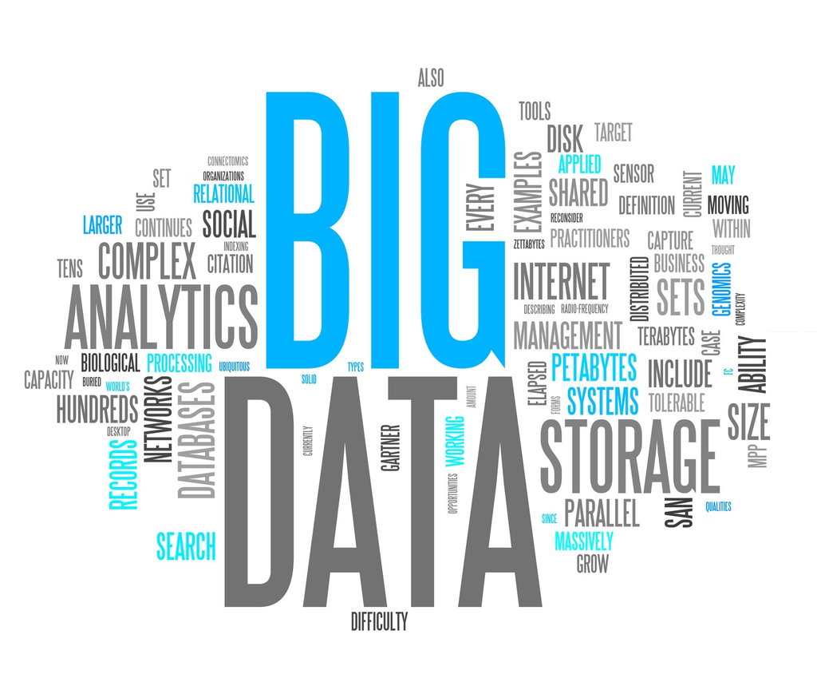

```python
from IPython.display import Image
Image("data/bigdata.png")
```

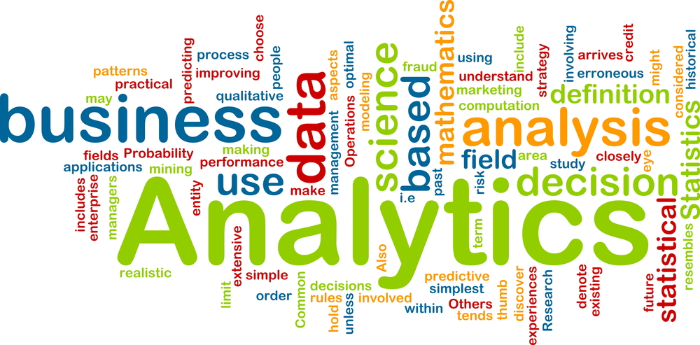

```python
# include bigdata1.png here.
from IPython.display import Image
Image("data/bigdata1.jpg")
```

```python
# include web image
from IPython.display import Image
from IPython.core.display import HTML
Image(url= "http://ipython.org/_static/sloangrant/9_home_fperez_prof_grants_1207-sloan-ipython_proposal_fig_ipython-notebook-specgram.png")
```

[figure not shown]

```python
# include an image from the web
from IPython.display import Image
from IPython.core.display import HTML
Image(url= "https://pbs.twimg.com/profile_images/1026512919435993089/PHNpO6F1_400x400.jpg")
```

[figure not shown]

```python
# include a video
from IPython.display import YouTubeVideo
YouTubeVideo('vKsaxP-M-Hc')
```

[video not shown]

```python
# include a Youtube video about data analytics, big data, ...

from IPython.display import YouTubeVideo
YouTubeVideo('77UPUxB2b7o')
```

[video not shown]

```python
# include your name and K-State Honor code in the blank cell below. Use Markdown and # to use a large font size for your name
```

# Nicole Becker, "On my honor, as a student, I have neither given nor received unauthorized aid on this academic work."¶

# What if you have questions on Python coding?

The best option is **Stackoverflow http://stackoverflow.com/**: It is most likely you will find the question you're asking and the solution for that. For example, your question is how to select all the rows related to the region East. Then,

- go to http://stackoverflow.com/
- search the following terms "pandas select rows". this will return this page http://stackoverflow.com/search?q=pandas+select+rows
- I would open one solution page http://stackoverflow.com/questions/17071871/select-rows-from-a-dataframe-based-on-values-in-a-column-in-pandas You will see many different solutions suggested by people. Try one of them. For example, one suggests: df.loc[df['column_name'] == some_value]
- simply adapt the suggested code in your ipython notebook

```python
# Read Excel file
import pandas as pd

data = pd.read_excel('data/sales_sample.xlsx')
data

#to read csv file
# data = pd.read_csv('data/sales_sample.csv')
```

|  | Order ID | Order Date | Order Quantity | Sales | Profit | Unit Price | Shipping Cost | Zip Code | Region | Customer Segment | Product Category | Product Sub-Category | Product Base Margin | Ship Date |
| --- | --- | --- | --- | --- | --- | --- | --- | --- | --- | --- | --- | --- | --- | --- |
| 0 | 3 | 2010-08-26 | 6 | 261.5400 | -213.2500 | 38.94 | 35.00 | 7514 | East | Small Business | Office Supplies | Storage & Organization | 0.80 | 2010-09-02 |
| 1 | 6 | 2012-01-03 | 2 | 6.9300 | -4.6400 | 2.08 | 2.56 | 10457 | East | Corporate | Office Supplies | Scissors, Rulers and Trimmers | 0.55 | 2012-01-04 |
| 2 | 32 | 2011-05-28 | 15 | 140.5600 | -128.3800 | 8.46 | 8.99 | 44197 | Central | Corporate | Technology | Computer Peripherals | 0.79 | 2011-05-29 |
| 3 | 32 | 2011-05-28 | 24 | 1761.4000 | -1748.5600 | 70.89 | 89.30 | 44197 | Central | Corporate | Furniture | Tables | 0.72 | 2011-05-29 |
| 4 | 32 | 2011-05-28 | 23 | 160.2335 | -85.1290 | 7.99 | 5.03 | 44197 | Central | Corporate | Technology | Telephones and Communication | 0.60 | 2011-05-30 |
| 5 | 32 | 2011-05-28 | 26 | 2808.0800 | 1054.8200 | 107.53 | 5.81 | 44197 | Central | Corporate | Furniture | Office Furnishings | 0.65 | 2011-05-30 |
| 6 | 35 | 2011-09-04 | 30 | 288.5600 | 60.7200 | 9.11 | 2.25 | 49822 | Central | Corporate | Office Supplies | Pens & Art Supplies | 0.52 | 2011-09-05 |
| 7 | 35 | 2011-09-04 | 14 | 1892.8480 | 48.9870 | 155.99 | 8.99 | 49822 | Central | Corporate | Technology | Telephones and Communication | 0.58 | 2011-09-06 |
| 8 | 36 | 2011-09-15 | 46 | 2484.7455 | 657.4770 | 65.99 | 4.20 | 6074 | East | Home Office | Technology | Telephones and Communication | 0.55 | 2011-09-15 |
| 9 | 65 | 2011-01-28 | 32 | 3812.7300 | 1470.3000 | 115.79 | 1.99 | 19936 | East | Corporate | Technology | Computer Peripherals | 0.49 | 2011-01-29 |
| 10 | 66 | 2008-12-02 | 41 | 108.1500 | 7.5700 | 2.88 | 0.70 | 27006 | South | Consumer | Office Supplies | Pens & Art Supplies | 0.56 | 2008-12-02 |
| 11 | 69 | 2009-04-16 | 42 | 1186.0600 | 511.6900 | 30.93 | 3.92 | 43567 | Central | Corporate | Furniture | Office Furnishings | 0.44 | 2009-04-18 |
| 12 | 69 | 2009-04-16 | 28 | 51.5300 | 0.3500 | 1.68 | 0.70 | 43567 | Central | Corporate | Office Supplies | Pens & Art Supplies | 0.60 | 2009-04-18 |
| 13 | 70 | 2010-10-30 | 46 | 7804.5300 | 2057.1660 | 205.99 | 5.99 | 27006 | South | Home Office | Technology | Telephones and Communication | 0.59 | 2010-11-04 |
| 14 | 70 | 2010-10-30 | 48 | 90.0500 | -107.0000 | 1.86 | 2.58 | 27006 | South | Home Office | Office Supplies | Rubber Bands | 0.82 | 2010-11-04 |
| 15 | 96 | 2009-02-27 | 37 | 4158.1235 | 1228.8870 | 125.99 | 8.99 | 73301 | Central | Home Office | Technology | Telephones and Communication | 0.55 | 2009-03-01 |
| 16 | 97 | 2009-12-11 | 26 | 75.5700 | 28.2400 | 2.89 | 0.50 | 85354 | West | Consumer | Office Supplies | Labels | 0.38 | 2009-12-12 |
| 17 | 129 | 2012-10-01 | 4 | 32.7200 | -22.5900 | 6.48 | 8.19 | 6439 | East | Corporate | Office Supplies | Paper | 0.37 | 2012-10-10 |
| 18 | 130 | 2012-03-20 | 29 | 575.1100 | 71.7500 | 18.97 | 9.03 | 32003 | South | Corporate | Office Supplies | Paper | 0.37 | 2012-03-21 |
| 19 | 130 | 2012-03-20 | 3 | 461.8900 | -356.1200 | 150.98 | 13.99 | 32003 | South | Corporate | Technology | Office Machines | 0.38 | 2012-03-22 |
| 20 | 130 | 2012-03-20 | 23 | 236.4600 | -134.3100 | 9.71 | 9.45 | 32003 | South | Corporate | Office Supplies | Storage & Organization | 0.60 | 2012-03-23 |
| 21 | 132 | 2010-04-23 | 27 | 192.8140 | -86.1960 | 7.99 | 5.03 | 21290 | South | Consumer | Technology | Telephones and Communication | 0.60 | 2010-04-24 |
| 22 | 132 | 2010-04-23 | 30 | 4011.6500 | -603.8000 | 130.98 | 54.74 | 21290 | South | Consumer | Furniture | Bookcases | 0.69 | 2010-04-26 |
| 23 | 134 | 2012-03-13 | 11 | 1132.6000 | -310.2100 | 95.99 | 35.00 | 81221 | West | Home Office | Office Supplies | Storage & Organization | 0.82 | 2012-03-15 |
| 24 | 135 | 2011-09-02 | 25 | 125.8500 | -89.2500 | 4.98 | 4.62 | 43054 | Central | Consumer | Technology | Computer Peripherals | 0.64 | 2011-09-04 |
| 25 | 166 | 2011-07-25 | 10 | 567.9360 | -126.0930 | 65.99 | 8.99 | 84001 | West | Consumer | Technology | Telephones and Communication | 0.55 | 2011-07-27 |
| 26 | 193 | 2010-06-20 | 14 | 174.8900 | -37.0400 | 12.44 | 6.27 | 85233 | West | Consumer | Office Supplies | Storage & Organization | 0.57 | 2010-06-22 |
| 27 | 194 | 2012-02-16 | 49 | 329.0300 | -197.2500 | 7.28 | 7.98 | 30002 | South | Corporate | Furniture | Office Furnishings | 0.42 | 2012-02-18 |
| 28 | 194 | 2012-02-16 | 6 | 20.1900 | -13.4400 | 3.14 | 1.92 | 30002 | South | Corporate | Office Supplies | Scissors, Rulers and Trimmers | 0.84 | 2012-02-18 |
| 29 | 195 | 2010-11-09 | 34 | 1315.7400 | 260.8700 | 36.55 | 13.89 | 6074 | East | Home Office | Office Supplies | Pens & Art Supplies | 0.41 | 2010-11-11 |
| ... | ... | ... | ... | ... | ... | ... | ... | ... | ... | ... | ... | ... | ... | ... |
| 970 | 7072 | 2011-12-18 | 29 | 258.6100 | -15.9620 | 8.85 | 5.60 | 98625 | West | Corporate | Office Supplies | Binders and Binder Accessories | 0.36 | 2011-12-18 |
| 971 | 7075 | 2011-08-23 | 15 | 241.8900 | -83.3000 | 15.42 | 10.68 | 93456 | West | Corporate | Office Supplies | Storage & Organization | 0.58 | 2011-08-25 |
| 972 | 7075 | 2011-08-23 | 43 | 83.3400 | -93.1800 | 1.86 | 2.58 | 93456 | West | Corporate | Office Supplies | Rubber Bands | 0.82 | 2011-08-27 |
| 973 | 7077 | 2011-11-03 | 14 | 304.5200 | 25.3400 | 21.78 | 5.94 | 83201 | West | Consumer | Office Supplies | Appliances | 0.50 | 2011-11-05 |
| 974 | 7078 | 2010-02-22 | 11 | 49.5800 | -47.0235 | 3.36 | 6.27 | 36350 | South | Corporate | Office Supplies | Binders and Binder Accessories | 0.40 | 2010-02-23 |
| 975 | 7078 | 2010-02-22 | 29 | 465.5200 | 65.3500 | 14.98 | 8.99 | 36350 | South | Corporate | Furniture | Office Furnishings | 0.39 | 2010-02-23 |
| 976 | 7078 | 2010-02-22 | 9 | 112.1200 | -8.4500 | 11.33 | 6.12 | 36350 | South | Corporate | Office Supplies | Appliances | 0.42 | 2010-02-24 |
| 977 | 7078 | 2010-02-22 | 16 | 1939.6500 | -885.7300 | 122.99 | 70.20 | 36350 | South | Corporate | Furniture | Chairs & Chairmats | 0.74 | 2010-02-24 |
| 978 | 7079 | 2009-12-22 | 44 | 12296.4900 | -416.7000 | 280.98 | 57.00 | 44197 | Central | Small Business | Furniture | Chairs & Chairmats | 0.78 | 2009-12-23 |
| 979 | 7079 | 2009-12-22 | 18 | 128.1300 | -34.9100 | 6.48 | 5.94 | 44197 | Central | Small Business | Office Supplies | Paper | 0.37 | 2009-12-24 |
| 980 | 7105 | 2010-05-04 | 17 | 77.1900 | -81.3500 | 4.06 | 6.89 | 35751 | South | Corporate | Office Supplies | Appliances | 0.60 | 2010-05-11 |
| 981 | 7106 | 2012-03-23 | 8 | 118.9800 | -12.7650 | 14.27 | 7.27 | 2139 | East | Home Office | Office Supplies | Binders and Binder Accessories | 0.38 | 2012-03-25 |
| 982 | 7106 | 2012-03-23 | 31 | 4910.0900 | 1669.3800 | 159.99 | 5.50 | 2139 | East | Home Office | Technology | Computer Peripherals | 0.49 | 2012-03-25 |
| 983 | 7106 | 2012-03-23 | 36 | 1058.4500 | -386.0200 | 27.75 | 19.99 | 2139 | East | Home Office | Office Supplies | Storage & Organization | 0.67 | 2012-03-25 |
| 984 | 7107 | 2011-11-17 | 3 | 172.0400 | 143.0800 | 54.20 | 11.10 | 27801 | South | Corporate | Furniture | Office Furnishings | 0.64 | 2011-11-17 |
| 985 | 7107 | 2011-11-17 | 32 | 1724.8200 | 407.8000 | 55.29 | 5.08 | 27801 | South | Corporate | Office Supplies | Storage & Organization | 0.59 | 2011-11-18 |
| 986 | 7107 | 2011-11-17 | 3 | 113.1400 | -21.2300 | 37.94 | 5.08 | 27801 | South | Corporate | Office Supplies | Paper | 0.38 | 2011-11-19 |
| 987 | 7110 | 2011-06-20 | 22 | 6396.2000 | 1902.2400 | 276.20 | 24.49 | 2139 | East | Corporate | Furniture | Chairs & Chairmats | 0.56 | 2011-06-24 |
| 988 | 7136 | 2009-02-02 | 17 | 642.9000 | 88.7200 | 39.48 | 1.99 | 49642 | Central | Home Office | Technology | Computer Peripherals | 0.54 | 2009-02-04 |
| 989 | 7136 | 2009-02-02 | 9 | 47.2800 | 17.0500 | 4.91 | 0.50 | 49642 | Central | Home Office | Office Supplies | Labels | 0.36 | 2009-02-04 |
| 990 | 7142 | 2011-06-03 | 36 | 132.8600 | 57.0000 | 3.69 | 0.50 | 83877 | West | Corporate | Office Supplies | Labels | 0.38 | 2011-06-05 |
| 991 | 7169 | 2010-02-06 | 30 | 1580.6005 | 303.5250 | 65.99 | 2.79 | 5544 | East | Corporate | Technology | Telephones and Communication | 0.56 | 2010-02-08 |
| 992 | 7169 | 2010-02-06 | 22 | 446.7200 | -39.0000 | 20.28 | 14.39 | 5544 | East | Corporate | Furniture | Office Furnishings | 0.47 | 2010-02-08 |
| 993 | 7171 | 2010-12-27 | 28 | 1703.8505 | 316.0620 | 65.99 | 8.99 | 88595 | Central | Consumer | Technology | Telephones and Communication | 0.58 | 2010-12-29 |
| 994 | 7171 | 2010-12-27 | 17 | 303.1865 | 92.5920 | 20.99 | 0.99 | 88595 | Central | Consumer | Technology | Telephones and Communication | 0.37 | 2010-12-29 |
| 995 | 7174 | 2012-01-22 | 10 | 141.9200 | 12.2000 | 13.73 | 8.99 | 96121 | West | Consumer | Furniture | Office Furnishings | 0.49 | 2012-01-24 |
| 996 | 7175 | 2009-12-21 | 10 | 748.2500 | -86.9900 | 70.98 | 26.74 | 81653 | West | Corporate | Furniture | Bookcases | 0.60 | 2009-12-23 |
| 997 | 7203 | 2008-11-21 | 25 | 21752.0100 | 9296.3480 | 896.99 | 19.99 | 10457 | East | Corporate | Office Supplies | Binders and Binder Accessories | 0.38 | 2008-11-23 |
| 998 | 7239 | 2011-05-12 | 50 | 6206.1600 | 1416.2700 | 120.33 | 19.99 | 83201 | West | Small Business | Office Supplies | Storage & Organization | 0.59 | 2011-05-14 |
| 999 | 7267 | 2012-07-11 | 19 | 262.3200 | 5.1595 | 14.48 | 6.46 | 14709 | East | Consumer | Office Supplies | Binders and Binder Accessories | 0.38 | 2012-07-11 |

1000 rows × 14 columns

```python
# sales from East region

east = data.loc[data['Region'] == "East"]
east.head()
```

|  | Order ID | Order Date | Order Quantity | Sales | Profit | Unit Price | Shipping Cost | Zip Code | Region | Customer Segment | Product Category | Product Sub-Category | Product Base Margin | Ship Date |
| --- | --- | --- | --- | --- | --- | --- | --- | --- | --- | --- | --- | --- | --- | --- |
| 0 | 3 | 2010-08-26 | 6 | 261.5400 | -213.250 | 38.94 | 35.00 | 7514 | East | Small Business | Office Supplies | Storage & Organization | 0.80 | 2010-09-02 |
| 1 | 6 | 2012-01-03 | 2 | 6.9300 | -4.640 | 2.08 | 2.56 | 10457 | East | Corporate | Office Supplies | Scissors, Rulers and Trimmers | 0.55 | 2012-01-04 |
| 8 | 36 | 2011-09-15 | 46 | 2484.7455 | 657.477 | 65.99 | 4.20 | 6074 | East | Home Office | Technology | Telephones and Communication | 0.55 | 2011-09-15 |
| 9 | 65 | 2011-01-28 | 32 | 3812.7300 | 1470.300 | 115.79 | 1.99 | 19936 | East | Corporate | Technology | Computer Peripherals | 0.49 | 2011-01-29 |
| 17 | 129 | 2012-10-01 | 4 | 32.7200 | -22.590 | 6.48 | 8.19 | 6439 | East | Corporate | Office Supplies | Paper | 0.37 | 2012-10-10 |

```python
# sales from East region

data.loc[data['Profit'] < 0]
```

|  | Order ID | Order Date | Order Quantity | Sales | Profit | Unit Price | Shipping Cost | Zip Code | Region | Customer Segment | Product Category | Product Sub-Category | Product Base Margin | Ship Date |
| --- | --- | --- | --- | --- | --- | --- | --- | --- | --- | --- | --- | --- | --- | --- |
| 0 | 3 | 2010-08-26 | 6 | 261.5400 | -213.2500 | 38.94 | 35.00 | 7514 | East | Small Business | Office Supplies | Storage & Organization | 0.80 | 2010-09-02 |
| 1 | 6 | 2012-01-03 | 2 | 6.9300 | -4.6400 | 2.08 | 2.56 | 10457 | East | Corporate | Office Supplies | Scissors, Rulers and Trimmers | 0.55 | 2012-01-04 |
| 2 | 32 | 2011-05-28 | 15 | 140.5600 | -128.3800 | 8.46 | 8.99 | 44197 | Central | Corporate | Technology | Computer Peripherals | 0.79 | 2011-05-29 |
| 3 | 32 | 2011-05-28 | 24 | 1761.4000 | -1748.5600 | 70.89 | 89.30 | 44197 | Central | Corporate | Furniture | Tables | 0.72 | 2011-05-29 |
| 4 | 32 | 2011-05-28 | 23 | 160.2335 | -85.1290 | 7.99 | 5.03 | 44197 | Central | Corporate | Technology | Telephones and Communication | 0.60 | 2011-05-30 |
| 14 | 70 | 2010-10-30 | 48 | 90.0500 | -107.0000 | 1.86 | 2.58 | 27006 | South | Home Office | Office Supplies | Rubber Bands | 0.82 | 2010-11-04 |
| 17 | 129 | 2012-10-01 | 4 | 32.7200 | -22.5900 | 6.48 | 8.19 | 6439 | East | Corporate | Office Supplies | Paper | 0.37 | 2012-10-10 |
| 19 | 130 | 2012-03-20 | 3 | 461.8900 | -356.1200 | 150.98 | 13.99 | 32003 | South | Corporate | Technology | Office Machines | 0.38 | 2012-03-22 |
| 20 | 130 | 2012-03-20 | 23 | 236.4600 | -134.3100 | 9.71 | 9.45 | 32003 | South | Corporate | Office Supplies | Storage & Organization | 0.60 | 2012-03-23 |
| 21 | 132 | 2010-04-23 | 27 | 192.8140 | -86.1960 | 7.99 | 5.03 | 21290 | South | Consumer | Technology | Telephones and Communication | 0.60 | 2010-04-24 |
| 22 | 132 | 2010-04-23 | 30 | 4011.6500 | -603.8000 | 130.98 | 54.74 | 21290 | South | Consumer | Furniture | Bookcases | 0.69 | 2010-04-26 |
| 23 | 134 | 2012-03-13 | 11 | 1132.6000 | -310.2100 | 95.99 | 35.00 | 81221 | West | Home Office | Office Supplies | Storage & Organization | 0.82 | 2012-03-15 |
| 24 | 135 | 2011-09-02 | 25 | 125.8500 | -89.2500 | 4.98 | 4.62 | 43054 | Central | Consumer | Technology | Computer Peripherals | 0.64 | 2011-09-04 |
| 25 | 166 | 2011-07-25 | 10 | 567.9360 | -126.0930 | 65.99 | 8.99 | 84001 | West | Consumer | Technology | Telephones and Communication | 0.55 | 2011-07-27 |
| 26 | 193 | 2010-06-20 | 14 | 174.8900 | -37.0400 | 12.44 | 6.27 | 85233 | West | Consumer | Office Supplies | Storage & Organization | 0.57 | 2010-06-22 |
| 27 | 194 | 2012-02-16 | 49 | 329.0300 | -197.2500 | 7.28 | 7.98 | 30002 | South | Corporate | Furniture | Office Furnishings | 0.42 | 2012-02-18 |
| 28 | 194 | 2012-02-16 | 6 | 20.1900 | -13.4400 | 3.14 | 1.92 | 30002 | South | Corporate | Office Supplies | Scissors, Rulers and Trimmers | 0.84 | 2012-02-18 |
| 31 | 224 | 2009-04-30 | 25 | 184.8600 | -33.9500 | 7.38 | 5.21 | 6439 | East | Corporate | Furniture | Office Furnishings | 0.56 | 2009-05-01 |
| 32 | 224 | 2009-04-30 | 33 | 528.5000 | -149.9200 | 15.42 | 10.68 | 6439 | East | Corporate | Office Supplies | Storage & Organization | 0.58 | 2009-05-01 |
| 33 | 224 | 2009-04-30 | 44 | 267.8500 | -65.4300 | 5.98 | 5.15 | 6439 | East | Corporate | Office Supplies | Paper | 0.36 | 2009-05-01 |
| 35 | 225 | 2011-04-06 | 1 | 23.7000 | -8.9700 | 19.84 | 4.10 | 27801 | South | Home Office | Office Supplies | Pens & Art Supplies | 0.44 | 2011-04-08 |
| 39 | 230 | 2010-09-08 | 11 | 1118.3960 | -212.3330 | 125.99 | 8.08 | 77474 | Central | Corporate | Technology | Telephones and Communication | 0.57 | 2010-09-10 |
| 40 | 231 | 2009-08-11 | 2 | 689.7400 | -490.8400 | 363.25 | 19.99 | 62999 | Central | Small Business | Office Supplies | Appliances | 0.57 | 2009-08-13 |
| 41 | 258 | 2010-11-10 | 7 | 201.3600 | -284.4000 | 20.98 | 53.03 | 27010 | South | Home Office | Office Supplies | Storage & Organization | 0.78 | 2010-11-11 |
| 42 | 258 | 2010-11-10 | 21 | 154.3500 | -91.1400 | 6.48 | 8.74 | 27010 | South | Home Office | Office Supplies | Paper | 0.36 | 2010-11-12 |
| 43 | 258 | 2010-11-10 | 33 | 216.7700 | -55.1080 | 6.54 | 5.27 | 27010 | South | Home Office | Office Supplies | Binders and Binder Accessories | 0.36 | 2010-11-12 |
| 45 | 263 | 2009-03-29 | 25 | 136.7700 | -136.2520 | 5.40 | 7.78 | 96061 | West | Corporate | Office Supplies | Binders and Binder Accessories | 0.37 | 2009-03-30 |
| 46 | 290 | 2008-11-13 | 24 | 188.7300 | -32.4800 | 7.64 | 5.83 | 28717 | South | Home Office | Office Supplies | Paper | 0.36 | 2008-11-14 |
| 52 | 322 | 2012-01-30 | 46 | 281.0000 | -291.5900 | 6.48 | 10.05 | 86409 | West | Corporate | Office Supplies | Paper | 0.37 | 2012-02-01 |
| 53 | 323 | 2009-02-05 | 2 | 55.3400 | -31.2400 | 22.84 | 11.54 | 85060 | West | Small Business | Office Supplies | Paper | 0.39 | 2009-02-07 |
| ... | ... | ... | ... | ... | ... | ... | ... | ... | ... | ... | ... | ... | ... | ... |
| 941 | 6848 | 2010-07-27 | 22 | 116.8400 | -125.4420 | 5.40 | 7.78 | 43270 | Central | Consumer | Office Supplies | Binders and Binder Accessories | 0.37 | 2010-07-28 |
| 942 | 6850 | 2009-12-25 | 8 | 81.5600 | -7.2300 | 10.01 | 1.99 | 11769 | East | Corporate | Technology | Computer Peripherals | 0.41 | 2009-12-25 |
| 944 | 6850 | 2009-12-25 | 26 | 3753.7200 | -556.2500 | 138.75 | 52.42 | 11769 | East | Corporate | Furniture | Tables | 0.74 | 2009-12-26 |
| 947 | 6854 | 2008-11-19 | 1 | 22.1300 | -2.3920 | 7.68 | 6.16 | 27114 | South | Consumer | Office Supplies | Binders and Binder Accessories | 0.35 | 2008-11-21 |
| 950 | 6884 | 2008-11-28 | 41 | 217.0000 | -61.2100 | 4.98 | 4.75 | 7010 | East | Home Office | Office Supplies | Paper | 0.36 | 2008-12-03 |
| 952 | 6885 | 2012-05-02 | 4 | 481.2700 | -181.2700 | 113.98 | 30.00 | 21230 | South | Corporate | Furniture | Chairs & Chairmats | 0.69 | 2012-05-04 |
| 955 | 6916 | 2010-04-17 | 40 | 436.1700 | -141.2700 | 10.90 | 7.46 | 19701 | East | Consumer | Office Supplies | Storage & Organization | 0.59 | 2010-04-21 |
| 957 | 6947 | 2011-06-01 | 9 | 520.4900 | -51.0100 | 51.65 | 18.45 | 78602 | Central | Small Business | Furniture | Office Furnishings | 0.65 | 2011-06-03 |
| 958 | 6948 | 2010-10-22 | 15 | 1143.8800 | -88.7000 | 73.98 | 4.00 | 98601 | West | Corporate | Technology | Computer Peripherals | 0.79 | 2010-10-23 |
| 959 | 6950 | 2012-02-07 | 4 | 187.3995 | -225.3020 | 55.99 | 3.30 | 39859 | South | Home Office | Technology | Telephones and Communication | 0.59 | 2012-02-09 |
| 960 | 6978 | 2010-10-22 | 47 | 371.9500 | -87.4000 | 8.12 | 2.83 | 60001 | Central | Home Office | Technology | Computer Peripherals | 0.77 | 2010-10-23 |
| 961 | 6979 | 2009-01-10 | 28 | 334.8900 | -1.6500 | 11.99 | 5.99 | 73301 | Central | Home Office | Technology | Office Machines | 0.36 | 2009-01-11 |
| 962 | 6980 | 2010-01-01 | 18 | 136.2900 | -77.2800 | 7.30 | 7.72 | 7981 | East | Consumer | Office Supplies | Binders and Binder Accessories | 0.38 | 2010-01-02 |
| 964 | 6982 | 2011-09-29 | 5 | 544.4100 | -338.2700 | 100.98 | 57.38 | 19701 | East | Corporate | Furniture | Bookcases | 0.78 | 2011-10-01 |
| 968 | 7042 | 2011-11-21 | 4 | 1187.8640 | -347.1600 | 376.13 | 85.63 | 34997 | South | Home Office | Furniture | Tables | 0.74 | 2011-11-23 |
| 969 | 7043 | 2008-12-08 | 4 | 11.0800 | -8.9300 | 1.74 | 4.08 | 39901 | South | Corporate | Furniture | Office Furnishings | 0.53 | 2008-12-09 |
| 970 | 7072 | 2011-12-18 | 29 | 258.6100 | -15.9620 | 8.85 | 5.60 | 98625 | West | Corporate | Office Supplies | Binders and Binder Accessories | 0.36 | 2011-12-18 |
| 971 | 7075 | 2011-08-23 | 15 | 241.8900 | -83.3000 | 15.42 | 10.68 | 93456 | West | Corporate | Office Supplies | Storage & Organization | 0.58 | 2011-08-25 |
| 972 | 7075 | 2011-08-23 | 43 | 83.3400 | -93.1800 | 1.86 | 2.58 | 93456 | West | Corporate | Office Supplies | Rubber Bands | 0.82 | 2011-08-27 |
| 974 | 7078 | 2010-02-22 | 11 | 49.5800 | -47.0235 | 3.36 | 6.27 | 36350 | South | Corporate | Office Supplies | Binders and Binder Accessories | 0.40 | 2010-02-23 |
| 976 | 7078 | 2010-02-22 | 9 | 112.1200 | -8.4500 | 11.33 | 6.12 | 36350 | South | Corporate | Office Supplies | Appliances | 0.42 | 2010-02-24 |
| 977 | 7078 | 2010-02-22 | 16 | 1939.6500 | -885.7300 | 122.99 | 70.20 | 36350 | South | Corporate | Furniture | Chairs & Chairmats | 0.74 | 2010-02-24 |
| 978 | 7079 | 2009-12-22 | 44 | 12296.4900 | -416.7000 | 280.98 | 57.00 | 44197 | Central | Small Business | Furniture | Chairs & Chairmats | 0.78 | 2009-12-23 |
| 979 | 7079 | 2009-12-22 | 18 | 128.1300 | -34.9100 | 6.48 | 5.94 | 44197 | Central | Small Business | Office Supplies | Paper | 0.37 | 2009-12-24 |
| 980 | 7105 | 2010-05-04 | 17 | 77.1900 | -81.3500 | 4.06 | 6.89 | 35751 | South | Corporate | Office Supplies | Appliances | 0.60 | 2010-05-11 |
| 981 | 7106 | 2012-03-23 | 8 | 118.9800 | -12.7650 | 14.27 | 7.27 | 2139 | East | Home Office | Office Supplies | Binders and Binder Accessories | 0.38 | 2012-03-25 |
| 983 | 7106 | 2012-03-23 | 36 | 1058.4500 | -386.0200 | 27.75 | 19.99 | 2139 | East | Home Office | Office Supplies | Storage & Organization | 0.67 | 2012-03-25 |
| 986 | 7107 | 2011-11-17 | 3 | 113.1400 | -21.2300 | 37.94 | 5.08 | 27801 | South | Corporate | Office Supplies | Paper | 0.38 | 2011-11-19 |
| 992 | 7169 | 2010-02-06 | 22 | 446.7200 | -39.0000 | 20.28 | 14.39 | 5544 | East | Corporate | Furniture | Office Furnishings | 0.47 | 2010-02-08 |
| 996 | 7175 | 2009-12-21 | 10 | 748.2500 | -86.9900 | 70.98 | 26.74 | 81653 | West | Corporate | Furniture | Bookcases | 0.60 | 2009-12-23 |

507 rows × 14 columns

```python
east.describe()
```

|  | Order ID | Order Quantity | Sales | Profit | Unit Price | Shipping Cost | Zip Code | Product Base Margin |
| --- | --- | --- | --- | --- | --- | --- | --- | --- |
| count | 206.000000 | 206.000000 | 206.000000 | 206.000000 | 206.000000 | 206.000000 | 206.000000 | 206.000000 |
| mean | 3603.490291 | 25.679612 | 1990.622104 | 221.812228 | 89.096845 | 14.308447 | 8790.252427 | 0.508010 |
| std | 2180.711360 | 14.389504 | 3644.045743 | 1347.105861 | 215.310550 | 18.381279 | 6190.031823 | 0.135501 |
| min | 3.000000 | 1.000000 | 5.680000 | -3996.390000 | 1.760000 | 0.500000 | 501.000000 | 0.350000 |
| 25% | 1699.750000 | 13.000000 | 143.752500 | -83.990000 | 6.480000 | 3.182500 | 5544.000000 | 0.380000 |
| 50% | 3490.000000 | 25.000000 | 507.810000 | -4.075000 | 22.780000 | 6.500000 | 6928.000000 | 0.495000 |
| 75% | 5490.500000 | 38.000000 | 1914.572500 | 165.685000 | 100.980000 | 17.625000 | 14210.000000 | 0.587500 |
| max | 7267.000000 | 50.000000 | 23281.050000 | 9296.348000 | 2550.140000 | 81.980000 | 19980.000000 | 0.850000 |

# Now, it is your turn. Your question is how to rename column names. Then,

- go to http://stackoverflow.com/
- search the following terms "pandas rename columns". this will return this page http://stackoverflow.com/search?q=pandas+rename+columns
- I would open the first solution on that page http://stackoverflow.com/questions/11346283/renaming-columns-in-pandas You will see many different solutions suggested by people. Try one of them. For example, one suggests: df = df.rename(columns={'$a': 'a', '$b': 'b'})
- simply adapt the suggested code in your ipython notebook

```python
# rename the column "Sales" to "Sales_Amount"
data = data.rename(columns={'Sales': 'Sales_Amount', 'Region': 'Market'})
data.head()
```

|  | Order ID | Order Date | Order Quantity | Sales_Amount | Profit | Unit Price | Shipping Cost | Zip Code | Market | Customer Segment | Product Category | Product Sub-Category | Product Base Margin | Ship Date |
| --- | --- | --- | --- | --- | --- | --- | --- | --- | --- | --- | --- | --- | --- | --- |
| 0 | 3 | 2010-08-26 | 6 | 261.5400 | -213.250 | 38.94 | 35.00 | 7514 | East | Small Business | Office Supplies | Storage & Organization | 0.80 | 2010-09-02 |
| 1 | 6 | 2012-01-03 | 2 | 6.9300 | -4.640 | 2.08 | 2.56 | 10457 | East | Corporate | Office Supplies | Scissors, Rulers and Trimmers | 0.55 | 2012-01-04 |
| 2 | 32 | 2011-05-28 | 15 | 140.5600 | -128.380 | 8.46 | 8.99 | 44197 | Central | Corporate | Technology | Computer Peripherals | 0.79 | 2011-05-29 |
| 3 | 32 | 2011-05-28 | 24 | 1761.4000 | -1748.560 | 70.89 | 89.30 | 44197 | Central | Corporate | Furniture | Tables | 0.72 | 2011-05-29 |
| 4 | 32 | 2011-05-28 | 23 | 160.2335 | -85.129 | 7.99 | 5.03 | 44197 | Central | Corporate | Technology | Telephones and Communication | 0.60 | 2011-05-30 |

# For HW Submission

- Rename this ipython notebook as Yourlastname_firstinitial_HW_PythonBootCamp
- Download this file as html (Go to **File** / **Download as HTML**)
- Submit it to Canvas

# Additional Resources

To learn more about Python programming in general, you are referred to the following online resources:

- https://pythonspot.com/python-numbers/ (a very short tutorial!)
- http://en.wikibooks.org/wiki/Non-Programmer%27s_Tutorial_for_Python_2.6/Lists (a comprehensive tutorial)

# Popular Python Packages for Data Analysis

- Numpy and Scipy – fundamental scientific computing.
- Pandas – data manipulation and analysis.
- Matplotlib – plotting and visualization.
- Seaborn - data visualization
- Scikit-learn – machine learning and data mining.
- StatsModels – statistical modeling, testing, and analysis.

# References

- https://pythonspot.com/python-lists/
- http://en.wikibooks.org/wiki/Non-Programmer%27s_Tutorial_for_Python_2.6/Lists